# Rapport, befolkning

Utgiven

21 september 2026

Ändrad

21 september 2026

# Introduktion

Denna rapport är en del av ett första alfatest av projektet Hugo. Syftet är att tillgängliggöra och visualisera befolkningsprognosen som finns för kommunen, vilket samtidigt ämnar visa vad som är möjligt redan i detta skede, i de fall data finns att tillgå.

**VarningOBS!**

Notera att rapporten i denna utvecklingsfas kan innehålla felaktigheter, då projektets testprocesser fortfarande är under konstruktion.

## Hur rapporten används

Till vänster finns navigationen som leder till varje rubrik. Flera av graferna i rapporten är interaktiva. I regel går de att följa med musen för att få mer detaljerad information, vänsterklicka och dra musen över ett område med musen för att zooma in, och dubbelklicka för att återställa. Vid flera av graferna kommer det också upp en mindre menyrad i övre högra hörnet av grafen när musen förs någonstans på den. Där går det att ändra inställningar för hur den ser ut, samt ladda ned en bild av hur den ser ut till sin egen dator. Några är dock inte interaktiva; jag har valt att lägga ut en markör vid dessa för att undvika eventuell förvirring.

För en snabb överblick av nyckeltalen finns även dashboarden för befolkning, som bygger på samma data.

# Grafer

Nedan kommer visualiseringar över befolkningsprognosen i olika former. Först ut är vanliga, om än interaktiva, linjegrafer. Därefter kommer staplade grafer. Avslutningsvis återfinns grafer som visar analytiska, potentiellt intressanta, utvecklingar.

**NoteraNotera:**

Det tonade fältet till höger i graferna markerar prognosperioden, det vill säga från och med 2026. Ofärgat område till vänster är historiskt utfall.

## Linjer

Den första grafen visar befolkningsmängdens utveckling när den betraktas som en helhet. Sedan 1980 har den, i stort sett, pekat nedåt; detta förväntas enligt prognosen fortsätta även fram till 2040.

[interactive chart not shown]

När vi splittrar helheten till åldersgrupper framträder ett tydligt skifte omkring ca 2008: medan grupperna yngre än 65 fortsatt att minska, pekar kurvan för 65+ istället uppåt. Båda dessa trender prognosticeras att fortsätta tills 2040, vilket ger en annan åldersmässig demografisk struktur än tidigare.

[interactive chart not shown]

## Staplade grafer

Den fortsatt förändrade åldersammansättning illustreras på ett annorlunda sätt i nedanstående staplade grafer, men tolkningen är densamma. Andelen av befolkningen som är över 65 förväntas därmed öka, medan särskilt de yngsta – de under 20 – förväntas stå för en allt mindre andel av befolkningen.

**NoteraEj interaktiv.**

Nedanstående grafer är ej interaktiv, utan är enbart en fast bild.

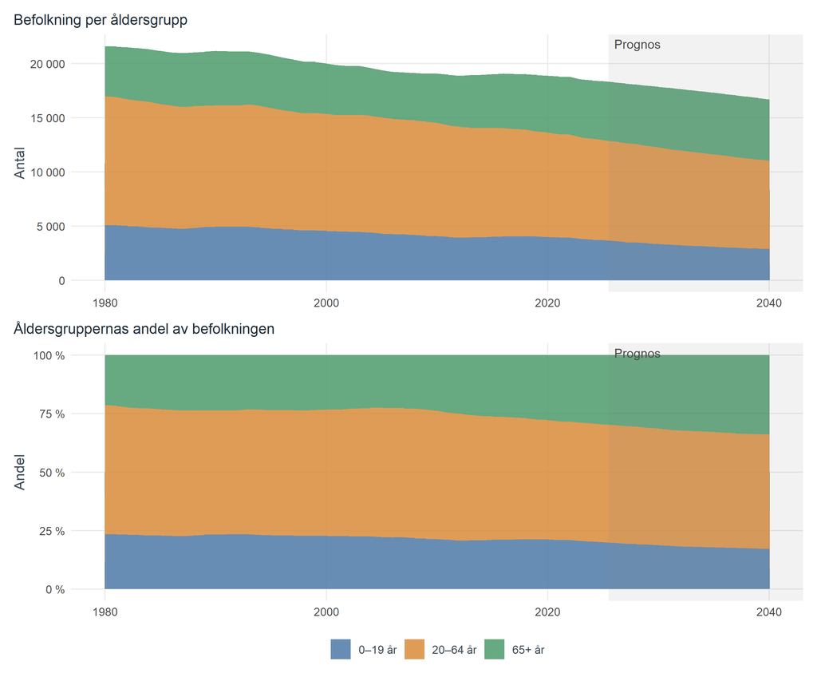

**TipsTips!**

Nedanstående graf *är* interaktiv, och går också att dra via reglaget under den för att ställa in önskat tidsomfång.

[interactive chart not shown]

## Analytiska grafer

Ett sådant demografiskt skifte som beskrivits ovan kan då också tolkas via nedanstående grafer. Om äldre ökar sin andel och yngre minskar sin andel, blir ett resultat att andelen av befolkningen som befinner sig däremellan (20-64 år gamla) över tid står för en allt mindre andel av befolkningen. Detta är en trend som går att utröna ur historisk data, där den blir särskilt tydlig sedan cirka 2009.

[interactive chart not shown]

Genom att använda ett index som gör förändringarna för varje åldersgrupp relativa, går det också att tydliggöra vilka skillnader som förväntas ske. Nedanstående graf är just en indexerad sådan, som tydligt visar hur utvecklingen sett ut historiskt och hur den förväntas bli framgent.

**NoteraAtt tolka ett index**

Att en graf är indexerad innebär att alla värden sätts till 100 i startpunkten, i det här fallet 1980, oavsett hur många de faktiskt är. Detta gör det möjligt att se en *relativ* utveckling genom procent. Exempelvis var mängden personer under 20 år gamla året 2012 ca 77,4% av den mängd de var 1980. Andelen 65+ hade dock ökat, och var ca 102,3% av den mängd de var 1980.

[interactive chart not shown]

Slutsatsen blir att både historisk data och den prognos som gjorts pekar på en kraftig ökning av antalet 65+, en kraftig minskning av de under 20, och en tydlig minskning av personer mellan 20 och 64. Detta gör också att andelen av befolkningen mellan de åldrarna förväntas sjunka över tid, medan äldre ökar kraftigt.

Den största anledningen går att se nedan:

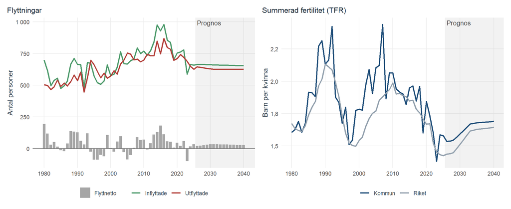

Trots en prognosticerad återhämtning av fertiliteten, både för Ljusdal och för riket, hävdar prognosen från Statisticon att den blir otillräcklig för att stabilisera befolkningens storlek. Den historiska och prognosticerade nettoinflyttningen blir då heller inte tillräcklig för att stabilisera utvecklingen.

# Samkörning med Kolada

En plattform som denna ger också möjligheten att på ett väsentligt smidigare sätt samla och nyttja data från andra kommuner via Koladas API. Ett kort exempel på kommuner som, gällande befolkningsutveckling, är intressanta att jämföra Ljusdal med och som hittats via just Koladas API följer nedan:

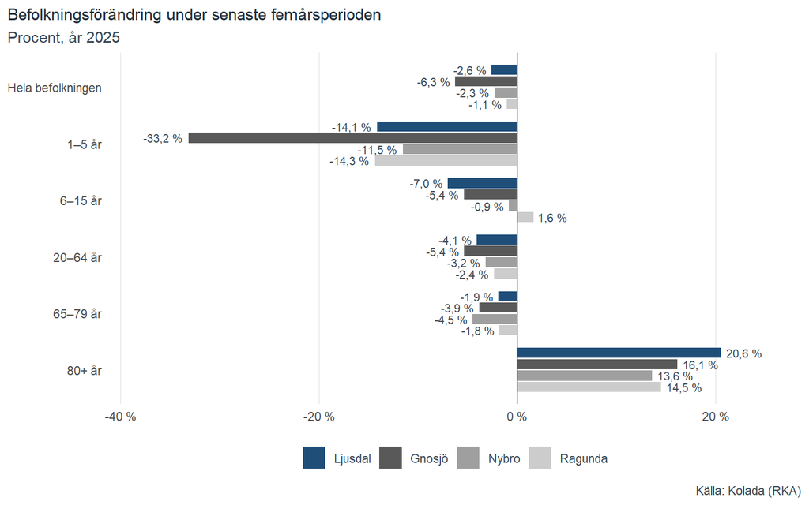

Den här rapporten är inte ämnad att göra någon närmare jämförelse mellan kommuner, hur dessa har hanterat eller förändrat sin demografiska situation, eller göra någon annan analytisk poäng. För det behövs det en utredning, där detta system - tillsammans med underliggande dataplattform - vore ovärdeliga, men som också kräver tid.

Min poäng är att det är *möjligt* att både hämta och spara data via Koladas API, vilket kan användas över tid. Att detta görs via system vi själva bestämmer över bör också innebära att det blir enklare att använda Koladas data mer aktivt i våra analyser, samtidigt som tydliggörandet av var data finns bör göra det till en mer integrerad del av de underlag som vi bygger än det är i dagsläget.

# Data

I nedanstående tabell finns den data som rapporten bygger på tillgänglig.

| År | 0–19 år | 20–64 år | 65+ år | Total befolkning |
| --- | --- | --- | --- | --- |
| 1980 | 5071 | 11920 | 4604 | 21595 |
| 1981 | 5068 | 11837 | 4668 | 21573 |
| 1982 | 5009 | 11698 | 4791 | 21498 |
| 1983 | 4963 | 11624 | 4839 | 21426 |
| 1984 | 4882 | 11586 | 4851 | 21319 |
| 1985 | 4859 | 11396 | 4906 | 21161 |
| 1986 | 4788 | 11333 | 4909 | 21030 |
| 1987 | 4743 | 11253 | 4962 | 20958 |
| 1988 | 4821 | 11248 | 4957 | 21026 |
| 1989 | 4910 | 11198 | 4987 | 21095 |

[output cut: 51 more lines]

**ViktigtANVÄND EJ INNAN KVALITETSKONTROLL!**

Så länge dessa varningar finns bör denna rapport ej användas som underlag, utan endast som demo.